# Risk Factor Analysis

## Outcome Variable

**Outcome Variable:** whz

## Predictor Variables

**Intervention Variable:** exclfeed36

**Adjustment Set:**

- arm
- sex
- W_mage
- meducyrs
- feducyrs
- hhwealth_quart
- hfoodsec
- W_mhtcm
- vagbrth
- W_gagebrth
- W_birthwt
- W_birthlen
- W_nrooms
- W_nchldlt5
- month
- brthmon
- W_parity
- impfloor
- impsan
- safeh20
- delta_W_mage
- delta_meducyrs
- delta_feducyrs
- delta_hhwealth_quart
- delta_hfoodsec
- delta_W_mhtcm
- delta_vagbrth
- delta_W_gagebrth
- delta_W_birthwt
- delta_W_birthlen
- delta_W_nrooms
- delta_W_nchldlt5
- delta_month
- delta_brthmon
- delta_W_parity
- delta_impfloor
- delta_impsan
- delta_safeh20

## Stratifying Variables

The analysis was stratified on these variable(s):

- agecat
- studyid
- country

## Data Summary

| agecat | studyid | country | exclfeed36 | n_cell | n |
| --- | --- | --- | --- | --- | --- |
| Birth | ki0047075b-MAL-ED | BANGLADESH | 1 | 58 | 230 |
| Birth | ki0047075b-MAL-ED | BANGLADESH | 0 | 172 | 230 |
| Birth | ki0047075b-MAL-ED | BRAZIL | 1 | 12 | 177 |
| Birth | ki0047075b-MAL-ED | BRAZIL | 0 | 165 | 177 |
| Birth | ki0047075b-MAL-ED | INDIA | 1 | 5 | 195 |
| Birth | ki0047075b-MAL-ED | INDIA | 0 | 190 | 195 |
| Birth | ki0047075b-MAL-ED | NEPAL | 1 | 11 | 167 |
| Birth | ki0047075b-MAL-ED | NEPAL | 0 | 156 | 167 |
| Birth | ki0047075b-MAL-ED | PERU | 1 | 15 | 266 |
| Birth | ki0047075b-MAL-ED | PERU | 0 | 251 | 266 |
| Birth | ki0047075b-MAL-ED | SOUTH AFRICA | 1 | 0 | 234 |
| Birth | ki0047075b-MAL-ED | SOUTH AFRICA | 0 | 234 | 234 |
| Birth | ki0047075b-MAL-ED | TANZANIA, UNITED REPUBLIC OF | 1 | 1 | 116 |
| Birth | ki0047075b-MAL-ED | TANZANIA, UNITED REPUBLIC OF | 0 | 115 | 116 |
| Birth | ki1000108-CMC-V-BCS-2002 | INDIA | 1 | 3 | 3 |
| Birth | ki1000108-CMC-V-BCS-2002 | INDIA | 0 | 0 | 3 |
| Birth | ki1000108-IRC | INDIA | 1 | 0 | 3 |
| Birth | ki1000108-IRC | INDIA | 0 | 3 | 3 |
| Birth | ki1000109-EE | PAKISTAN | 1 | 0 | 1 |
| Birth | ki1000109-EE | PAKISTAN | 0 | 1 | 1 |
| Birth | ki1101329-Keneba | GAMBIA | 1 | 345 | 1202 |
| Birth | ki1101329-Keneba | GAMBIA | 0 | 857 | 1202 |
| Birth | kiGH5241-JiVitA-3 | BANGLADESH | 1 | 9175 | 11319 |
| Birth | kiGH5241-JiVitA-3 | BANGLADESH | 0 | 2144 | 11319 |
| Birth | kiGH5241-JiVitA-4 | BANGLADESH | 1 | 491 | 602 |
| Birth | kiGH5241-JiVitA-4 | BANGLADESH | 0 | 111 | 602 |
| 6 months | ki0047075b-MAL-ED | BANGLADESH | 1 | 63 | 240 |
| 6 months | ki0047075b-MAL-ED | BANGLADESH | 0 | 177 | 240 |
| 6 months | ki0047075b-MAL-ED | BRAZIL | 1 | 17 | 209 |
| 6 months | ki0047075b-MAL-ED | BRAZIL | 0 | 192 | 209 |

[output cut: 60 more lines]

The following strata were considered:

- agecat: 24 months, studyid: ki0047075b-MAL-ED, country: BANGLADESH
- agecat: 24 months, studyid: ki0047075b-MAL-ED, country: BRAZIL
- agecat: 24 months, studyid: ki0047075b-MAL-ED, country: INDIA
- agecat: 24 months, studyid: ki0047075b-MAL-ED, country: NEPAL
- agecat: 24 months, studyid: ki0047075b-MAL-ED, country: PERU
- agecat: 24 months, studyid: ki0047075b-MAL-ED, country: SOUTH AFRICA
- agecat: 24 months, studyid: ki0047075b-MAL-ED, country: TANZANIA, UNITED REPUBLIC OF
- agecat: 24 months, studyid: ki1000108-CMC-V-BCS-2002, country: INDIA
- agecat: 24 months, studyid: ki1000108-IRC, country: INDIA
- agecat: 24 months, studyid: ki1017093b-PROVIDE, country: BANGLADESH
- agecat: 24 months, studyid: ki1101329-Keneba, country: GAMBIA
- agecat: 24 months, studyid: ki1113344-GMS-Nepal, country: NEPAL
- agecat: 24 months, studyid: ki1148112-LCNI-5, country: MALAWI
- agecat: 24 months, studyid: kiGH5241-JiVitA-3, country: BANGLADESH
- agecat: 24 months, studyid: kiGH5241-JiVitA-4, country: BANGLADESH
- agecat: 6 months, studyid: ki0047075b-MAL-ED, country: BANGLADESH
- agecat: 6 months, studyid: ki0047075b-MAL-ED, country: BRAZIL
- agecat: 6 months, studyid: ki0047075b-MAL-ED, country: INDIA
- agecat: 6 months, studyid: ki0047075b-MAL-ED, country: NEPAL
- agecat: 6 months, studyid: ki0047075b-MAL-ED, country: PERU
- agecat: 6 months, studyid: ki0047075b-MAL-ED, country: SOUTH AFRICA
- agecat: 6 months, studyid: ki0047075b-MAL-ED, country: TANZANIA, UNITED REPUBLIC OF
- agecat: 6 months, studyid: ki1000108-CMC-V-BCS-2002, country: INDIA
- agecat: 6 months, studyid: ki1000108-IRC, country: INDIA
- agecat: 6 months, studyid: ki1000109-EE, country: PAKISTAN
- agecat: 6 months, studyid: ki1000304b-SAS-FoodSuppl, country: INDIA
- agecat: 6 months, studyid: ki1017093b-PROVIDE, country: BANGLADESH
- agecat: 6 months, studyid: ki1101329-Keneba, country: GAMBIA
- agecat: 6 months, studyid: ki1113344-GMS-Nepal, country: NEPAL
- agecat: 6 months, studyid: ki1148112-LCNI-5, country: MALAWI
- agecat: 6 months, studyid: kiGH5241-JiVitA-3, country: BANGLADESH
- agecat: 6 months, studyid: kiGH5241-JiVitA-4, country: BANGLADESH
- agecat: Birth, studyid: ki0047075b-MAL-ED, country: BANGLADESH
- agecat: Birth, studyid: ki0047075b-MAL-ED, country: BRAZIL
- agecat: Birth, studyid: ki0047075b-MAL-ED, country: INDIA
- agecat: Birth, studyid: ki0047075b-MAL-ED, country: NEPAL
- agecat: Birth, studyid: ki0047075b-MAL-ED, country: PERU
- agecat: Birth, studyid: ki0047075b-MAL-ED, country: SOUTH AFRICA
- agecat: Birth, studyid: ki0047075b-MAL-ED, country: TANZANIA, UNITED REPUBLIC OF
- agecat: Birth, studyid: ki1000108-CMC-V-BCS-2002, country: INDIA
- agecat: Birth, studyid: ki1000108-IRC, country: INDIA
- agecat: Birth, studyid: ki1000109-EE, country: PAKISTAN
- agecat: Birth, studyid: ki1101329-Keneba, country: GAMBIA
- agecat: Birth, studyid: kiGH5241-JiVitA-3, country: BANGLADESH
- agecat: Birth, studyid: kiGH5241-JiVitA-4, country: BANGLADESH

### Dropped Strata

- agecat: Birth, studyid: ki0047075b-MAL-ED, country: SOUTH AFRICA
- agecat: Birth, studyid: ki0047075b-MAL-ED, country: TANZANIA, UNITED REPUBLIC OF
- agecat: Birth, studyid: ki1000108-CMC-V-BCS-2002, country: INDIA
- agecat: Birth, studyid: ki1000108-IRC, country: INDIA
- agecat: Birth, studyid: ki1000109-EE, country: PAKISTAN
- agecat: 6 months, studyid: ki0047075b-MAL-ED, country: SOUTH AFRICA
- agecat: 6 months, studyid: ki0047075b-MAL-ED, country: TANZANIA, UNITED REPUBLIC OF
- agecat: 6 months, studyid: ki1000108-CMC-V-BCS-2002, country: INDIA
- agecat: 6 months, studyid: ki1000108-IRC, country: INDIA
- agecat: 6 months, studyid: ki1000304b-SAS-FoodSuppl, country: INDIA
- agecat: 24 months, studyid: ki0047075b-MAL-ED, country: SOUTH AFRICA
- agecat: 24 months, studyid: ki0047075b-MAL-ED, country: TANZANIA, UNITED REPUBLIC OF
- agecat: 24 months, studyid: ki1000108-CMC-V-BCS-2002, country: INDIA
- agecat: 24 months, studyid: ki1000108-IRC, country: INDIA

## Methods Detail

We’re interested in the causal parameters $E[Y_a]$ for all values of $a \in \mathcal{A}$. These parameters represent the mean outcome if, possibly contrary to fact, we intervened to set all units to have $A=a$. Under the randomization and positivity assumptions, these are identified by the statistical parameters $\psi_a=E_W[E_{Y|A,W}(Y|A=a,W)]$. In addition, we’re interested in the mean of $Y$, $E[Y]$ under no intervention (the observed mean). We will estimate these parameters by using SuperLearner to fit the relevant likelihood factors – $E_{Y|A,W}(Y|A=a,W)$ and $p(A=a|W)$, and then updating our likelihood fit using a joint TMLE.

For unadjusted analyses ($W=\{\}$), initial likelihoods were estimated using Lrnr_glm to estimate the simple $E(Y|A)$ and Lrnr_mean to estimate $p(A)$. For adjusted analyses, a small library containing Lrnr_glmnet, Lrnr_xgboost, and Lrnr_mean was used.

Having estimated these parameters, we will then use the delta method to estimate relative risks and attributable risks relative to a prespecified baseline level of $A$.

# Results Detail

## Results Plots

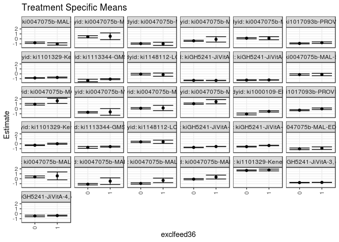

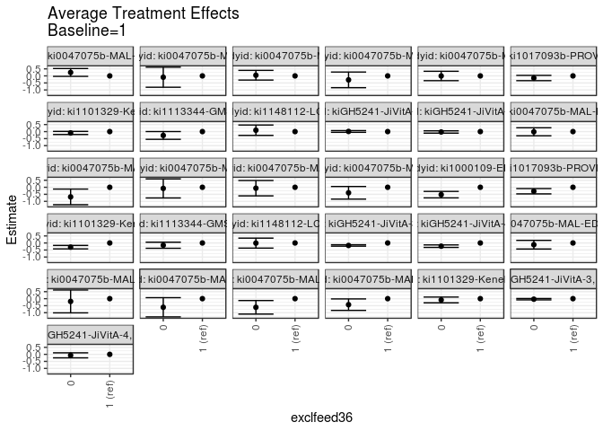

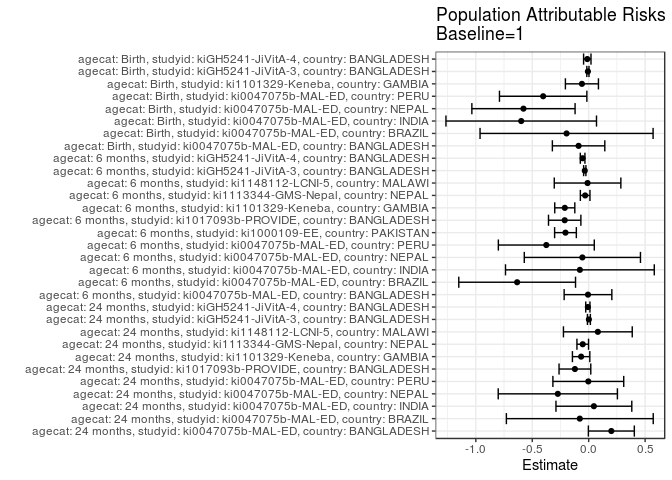

## Results Table

### Parameter: TSM

| agecat | studyid | country | intervention_level | baseline_level | estimate | ci_lower | ci_upper |
| --- | --- | --- | --- | --- | --- | --- | --- |
| Birth | ki0047075b-MAL-ED | BANGLADESH | 1 | NA | -0.8878442 | -1.1479950 | -0.6276933 |
| Birth | ki0047075b-MAL-ED | BANGLADESH | 0 | NA | -1.0104873 | -1.1733929 | -0.8475817 |
| Birth | ki0047075b-MAL-ED | BRAZIL | 1 | NA | 0.5796436 | -0.2120353 | 1.3713225 |
| Birth | ki0047075b-MAL-ED | BRAZIL | 0 | NA | 0.3835290 | 0.1997080 | 0.5673499 |
| Birth | ki0047075b-MAL-ED | INDIA | 1 | NA | -0.4840000 | -1.1529255 | 0.1849255 |
| Birth | ki0047075b-MAL-ED | INDIA | 0 | NA | -1.0973684 | -1.2418489 | -0.9528879 |
| Birth | ki0047075b-MAL-ED | NEPAL | 1 | NA | -0.3349243 | -0.7948904 | 0.1250419 |
| Birth | ki0047075b-MAL-ED | NEPAL | 0 | NA | -0.9497688 | -1.0938913 | -0.8056464 |
| Birth | ki0047075b-MAL-ED | PERU | 1 | NA | 0.3430579 | -0.0484898 | 0.7346057 |
| Birth | ki0047075b-MAL-ED | PERU | 0 | NA | -0.0842009 | -0.2009005 | 0.0324987 |
| Birth | ki1101329-Keneba | GAMBIA | 1 | NA | 1.7614009 | 1.5834886 | 1.9393132 |
| Birth | ki1101329-Keneba | GAMBIA | 0 | NA | 1.6703342 | 1.5685762 | 1.7720922 |
| Birth | kiGH5241-JiVitA-3 | BANGLADESH | 1 | NA | -0.7376746 | -0.7625038 | -0.7128455 |
| Birth | kiGH5241-JiVitA-3 | BANGLADESH | 0 | NA | -0.7741907 | -0.8218779 | -0.7265035 |
| Birth | kiGH5241-JiVitA-4 | BANGLADESH | 1 | NA | -0.3738334 | -0.4679708 | -0.2796960 |
| Birth | kiGH5241-JiVitA-4 | BANGLADESH | 0 | NA | -0.4430967 | -0.6055896 | -0.2806038 |
| 6 months | ki0047075b-MAL-ED | BANGLADESH | 1 | NA | -0.1339039 | -0.3738957 | 0.1060880 |
| 6 months | ki0047075b-MAL-ED | BANGLADESH | 0 | NA | -0.1480104 | -0.3023808 | 0.0063601 |
| 6 months | ki0047075b-MAL-ED | BRAZIL | 1 | NA | 1.6055068 | 1.0771739 | 2.1338396 |
| 6 months | ki0047075b-MAL-ED | BRAZIL | 0 | NA | 0.9215514 | 0.7495711 | 1.0935316 |
| 6 months | ki0047075b-MAL-ED | INDIA | 1 | NA | -0.6254762 | -1.2926685 | 0.0417161 |
| 6 months | ki0047075b-MAL-ED | INDIA | 0 | NA | -0.7057787 | -0.8330997 | -0.5784578 |
| 6 months | ki0047075b-MAL-ED | NEPAL | 1 | NA | 0.1669513 | -0.3647101 | 0.6986127 |
| 6 months | ki0047075b-MAL-ED | NEPAL | 0 | NA | 0.1017723 | -0.0339850 | 0.2375295 |
| 6 months | ki0047075b-MAL-ED | PERU | 1 | NA | 1.4315712 | 1.0027328 | 1.8604096 |
| 6 months | ki0047075b-MAL-ED | PERU | 0 | NA | 1.0385840 | 0.9109643 | 1.1662037 |
| 6 months | ki1000109-EE | PAKISTAN | 1 | NA | -0.5199896 | -0.6602748 | -0.3797044 |
| 6 months | ki1000109-EE | PAKISTAN | 0 | NA | -1.0432520 | -1.2264408 | -0.8600632 |
| 6 months | ki1017093b-PROVIDE | BANGLADESH | 1 | NA | 0.0041838 | -0.1575266 | 0.1658941 |
| 6 months | ki1017093b-PROVIDE | BANGLADESH | 0 | NA | -0.2776852 | -0.3752365 | -0.1801339 |
| 6 months | ki1101329-Keneba | GAMBIA | 1 | NA | 0.0108229 | -0.0955246 | 0.1171704 |
| 6 months | ki1101329-Keneba | GAMBIA | 0 | NA | -0.2868174 | -0.3505565 | -0.2230783 |
| 6 months | ki1113344-GMS-Nepal | NEPAL | 1 | NA | -0.5695152 | -0.6698690 | -0.4691615 |
| 6 months | ki1113344-GMS-Nepal | NEPAL | 0 | NA | -0.7296813 | -0.9204743 | -0.5388882 |
| 6 months | ki1148112-LCNI-5 | MALAWI | 1 | NA | 0.4026825 | 0.0712717 | 0.7340933 |
| 6 months | ki1148112-LCNI-5 | MALAWI | 0 | NA | 0.3923807 | 0.2651572 | 0.5196042 |
| 6 months | kiGH5241-JiVitA-3 | BANGLADESH | 1 | NA | -0.5488304 | -0.5724340 | -0.5252269 |
| 6 months | kiGH5241-JiVitA-3 | BANGLADESH | 0 | NA | -0.7269935 | -0.7744287 | -0.6795583 |
| 6 months | kiGH5241-JiVitA-4 | BANGLADESH | 1 | NA | -0.3435535 | -0.3909067 | -0.2962002 |
| 6 months | kiGH5241-JiVitA-4 | BANGLADESH | 0 | NA | -0.5710718 | -0.6482079 | -0.4939357 |
| 24 months | ki0047075b-MAL-ED | BANGLADESH | 1 | NA | -1.0236263 | -1.2601698 | -0.7870829 |
| 24 months | ki0047075b-MAL-ED | BANGLADESH | 0 | NA | -0.7776362 | -0.9214792 | -0.6337933 |
| 24 months | ki0047075b-MAL-ED | BRAZIL | 1 | NA | 0.5252569 | -0.1533270 | 1.2038408 |
| 24 months | ki0047075b-MAL-ED | BRAZIL | 0 | NA | 0.4311438 | 0.2142407 | 0.6480470 |
| 24 months | ki0047075b-MAL-ED | INDIA | 1 | NA | -0.9983333 | -1.3225137 | -0.6741530 |
| 24 months | ki0047075b-MAL-ED | INDIA | 0 | NA | -0.9510407 | -1.0692101 | -0.8328714 |
| 24 months | ki0047075b-MAL-ED | NEPAL | 1 | NA | -0.1029377 | -0.6467751 | 0.4408997 |
| 24 months | ki0047075b-MAL-ED | NEPAL | 0 | NA | -0.3856816 | -0.5023967 | -0.2689666 |
| 24 months | ki0047075b-MAL-ED | PERU | 1 | NA | 0.1335060 | -0.1788054 | 0.4458175 |
| 24 months | ki0047075b-MAL-ED | PERU | 0 | NA | 0.1286621 | 0.0041120 | 0.2532122 |
| 24 months | ki1017093b-PROVIDE | BANGLADESH | 1 | NA | -0.7675801 | -0.9279283 | -0.6072319 |
| 24 months | ki1017093b-PROVIDE | BANGLADESH | 0 | NA | -0.9187932 | -1.0160195 | -0.8215669 |
| 24 months | ki1101329-Keneba | GAMBIA | 1 | NA | -0.7303947 | -0.8231248 | -0.6376647 |
| 24 months | ki1101329-Keneba | GAMBIA | 0 | NA | -0.8269260 | -0.8894975 | -0.7643545 |
| 24 months | ki1113344-GMS-Nepal | NEPAL | 1 | NA | -1.0659997 | -1.1645624 | -0.9674370 |
| 24 months | ki1113344-GMS-Nepal | NEPAL | 0 | NA | -1.3401967 | -1.5978981 | -1.0824954 |
| 24 months | ki1148112-LCNI-5 | MALAWI | 1 | NA | -0.1582699 | -0.4876230 | 0.1710833 |
| 24 months | ki1148112-LCNI-5 | MALAWI | 0 | NA | -0.0597407 | -0.2223558 | 0.1028744 |
| 24 months | kiGH5241-JiVitA-3 | BANGLADESH | 1 | NA | -1.3265301 | -1.3572718 | -1.2957885 |
| 24 months | kiGH5241-JiVitA-3 | BANGLADESH | 0 | NA | -1.3167780 | -1.3726961 | -1.2608600 |
| 24 months | kiGH5241-JiVitA-4 | BANGLADESH | 1 | NA | -1.2343782 | -1.2726044 | -1.1961520 |
| 24 months | kiGH5241-JiVitA-4 | BANGLADESH | 0 | NA | -1.2624149 | -1.3377583 | -1.1870714 |

### Parameter: E(Y)

| agecat | studyid | country | intervention_level | baseline_level | estimate | ci_lower | ci_upper |
| --- | --- | --- | --- | --- | --- | --- | --- |
| Birth | ki0047075b-MAL-ED | BANGLADESH | NA | NA | -0.9773043 | -1.1153078 | -0.8393008 |
| Birth | ki0047075b-MAL-ED | BRAZIL | NA | NA | 0.3837288 | 0.2059602 | 0.5614974 |
| Birth | ki0047075b-MAL-ED | INDIA | NA | NA | -1.0816410 | -1.2241126 | -0.9391694 |
| Birth | ki0047075b-MAL-ED | NEPAL | NA | NA | -0.9126946 | -1.0520834 | -0.7733058 |
| Birth | ki0047075b-MAL-ED | PERU | NA | NA | -0.0602256 | -0.1729666 | 0.0525155 |
| Birth | ki1101329-Keneba | GAMBIA | NA | NA | 1.7015141 | 1.6127308 | 1.7902975 |
| Birth | kiGH5241-JiVitA-3 | BANGLADESH | NA | NA | -0.7445605 | -0.7677110 | -0.7214100 |
| Birth | kiGH5241-JiVitA-4 | BANGLADESH | NA | NA | -0.3861794 | -0.4712311 | -0.3011277 |
| 6 months | ki0047075b-MAL-ED | BANGLADESH | NA | NA | -0.1400243 | -0.2696346 | -0.0104140 |
| 6 months | ki0047075b-MAL-ED | BRAZIL | NA | NA | 0.9717225 | 0.8073791 | 1.1360658 |
| 6 months | ki0047075b-MAL-ED | INDIA | NA | NA | -0.7033969 | -0.8285284 | -0.5782654 |
| 6 months | ki0047075b-MAL-ED | NEPAL | NA | NA | 0.1110452 | -0.0202712 | 0.2423616 |
| 6 months | ki0047075b-MAL-ED | PERU | NA | NA | 1.0562362 | 0.9338834 | 1.1785889 |
| 6 months | ki1000109-EE | PAKISTAN | NA | NA | -0.7256065 | -0.8395859 | -0.6116270 |
| 6 months | ki1017093b-PROVIDE | BANGLADESH | NA | NA | -0.2083706 | -0.2927992 | -0.1239419 |
| 6 months | ki1101329-Keneba | GAMBIA | NA | NA | -0.2009677 | -0.2562623 | -0.1456731 |
| 6 months | ki1113344-GMS-Nepal | NEPAL | NA | NA | -0.6007161 | -0.6897580 | -0.5116742 |
| 6 months | ki1148112-LCNI-5 | MALAWI | NA | NA | 0.3927574 | 0.2737700 | 0.5117448 |
| 6 months | kiGH5241-JiVitA-3 | BANGLADESH | NA | NA | -0.5834618 | -0.6054534 | -0.5614701 |
| 6 months | kiGH5241-JiVitA-4 | BANGLADESH | NA | NA | -0.3973178 | -0.4385298 | -0.3561058 |
| 24 months | ki0047075b-MAL-ED | BANGLADESH | NA | NA | -0.8227962 | -0.9454140 | -0.7001785 |
| 24 months | ki0047075b-MAL-ED | BRAZIL | NA | NA | 0.4466272 | 0.2416144 | 0.6516401 |
| 24 months | ki0047075b-MAL-ED | INDIA | NA | NA | -0.9522907 | -1.0676596 | -0.8369219 |
| 24 months | ki0047075b-MAL-ED | NEPAL | NA | NA | -0.3764474 | -0.4898516 | -0.2630431 |
| 24 months | ki0047075b-MAL-ED | PERU | NA | NA | 0.1302000 | 0.0113848 | 0.2490152 |
| 24 months | ki1017093b-PROVIDE | BANGLADESH | NA | NA | -0.8896181 | -0.9727493 | -0.8064868 |
| 24 months | ki1101329-Keneba | GAMBIA | NA | NA | -0.7973955 | -0.8498696 | -0.7449213 |
| 24 months | ki1113344-GMS-Nepal | NEPAL | NA | NA | -1.1186923 | -1.2105469 | -1.0268377 |
| 24 months | ki1148112-LCNI-5 | MALAWI | NA | NA | -0.0771196 | -0.2204715 | 0.0662323 |
| 24 months | kiGH5241-JiVitA-3 | BANGLADESH | NA | NA | -1.3246418 | -1.3519597 | -1.2973238 |
| 24 months | kiGH5241-JiVitA-4 | BANGLADESH | NA | NA | -1.2418558 | -1.2769820 | -1.2067296 |

### Parameter: ATE

| agecat | studyid | country | intervention_level | baseline_level | estimate | ci_lower | ci_upper |
| --- | --- | --- | --- | --- | --- | --- | --- |
| Birth | ki0047075b-MAL-ED | BANGLADESH | 1 | 1 | 0.0000000 | 0.0000000 | 0.0000000 |
| Birth | ki0047075b-MAL-ED | BANGLADESH | 0 | 1 | -0.1226431 | -0.4304222 | 0.1851359 |
| Birth | ki0047075b-MAL-ED | BRAZIL | 1 | 1 | 0.0000000 | 0.0000000 | 0.0000000 |
| Birth | ki0047075b-MAL-ED | BRAZIL | 0 | 1 | -0.1961146 | -1.0087393 | 0.6165100 |
| Birth | ki0047075b-MAL-ED | INDIA | 1 | 1 | 0.0000000 | 0.0000000 | 0.0000000 |
| Birth | ki0047075b-MAL-ED | INDIA | 0 | 1 | -0.6133684 | -1.2977192 | 0.0709824 |
| Birth | ki0047075b-MAL-ED | NEPAL | 1 | 1 | 0.0000000 | 0.0000000 | 0.0000000 |
| Birth | ki0047075b-MAL-ED | NEPAL | 0 | 1 | -0.6148445 | -1.0968889 | -0.1328002 |
| Birth | ki0047075b-MAL-ED | PERU | 1 | 1 | 0.0000000 | 0.0000000 | 0.0000000 |
| Birth | ki0047075b-MAL-ED | PERU | 0 | 1 | -0.4272589 | -0.8359067 | -0.0186110 |
| Birth | ki1101329-Keneba | GAMBIA | 1 | 1 | 0.0000000 | 0.0000000 | 0.0000000 |
| Birth | ki1101329-Keneba | GAMBIA | 0 | 1 | -0.0910667 | -0.2962537 | 0.1141203 |
| Birth | kiGH5241-JiVitA-3 | BANGLADESH | 1 | 1 | 0.0000000 | 0.0000000 | 0.0000000 |
| Birth | kiGH5241-JiVitA-3 | BANGLADESH | 0 | 1 | -0.0365161 | -0.0863382 | 0.0133061 |
| Birth | kiGH5241-JiVitA-4 | BANGLADESH | 1 | 1 | 0.0000000 | 0.0000000 | 0.0000000 |
| Birth | kiGH5241-JiVitA-4 | BANGLADESH | 0 | 1 | -0.0692633 | -0.2482291 | 0.1097025 |
| 6 months | ki0047075b-MAL-ED | BANGLADESH | 1 | 1 | 0.0000000 | 0.0000000 | 0.0000000 |
| 6 months | ki0047075b-MAL-ED | BANGLADESH | 0 | 1 | -0.0141065 | -0.2997919 | 0.2715788 |
| 6 months | ki0047075b-MAL-ED | BRAZIL | 1 | 1 | 0.0000000 | 0.0000000 | 0.0000000 |
| 6 months | ki0047075b-MAL-ED | BRAZIL | 0 | 1 | -0.6839554 | -1.2413052 | -0.1266057 |
| 6 months | ki0047075b-MAL-ED | INDIA | 1 | 1 | 0.0000000 | 0.0000000 | 0.0000000 |
| 6 months | ki0047075b-MAL-ED | INDIA | 0 | 1 | -0.0803026 | -0.7595346 | 0.5989295 |
| 6 months | ki0047075b-MAL-ED | NEPAL | 1 | 1 | 0.0000000 | 0.0000000 | 0.0000000 |
| 6 months | ki0047075b-MAL-ED | NEPAL | 0 | 1 | -0.0651790 | -0.6109131 | 0.4805550 |
| 6 months | ki0047075b-MAL-ED | PERU | 1 | 1 | 0.0000000 | 0.0000000 | 0.0000000 |
| 6 months | ki0047075b-MAL-ED | PERU | 0 | 1 | -0.3929872 | -0.8420931 | 0.0561186 |
| 6 months | ki1000109-EE | PAKISTAN | 1 | 1 | 0.0000000 | 0.0000000 | 0.0000000 |
| 6 months | ki1000109-EE | PAKISTAN | 0 | 1 | -0.5232623 | -0.7542999 | -0.2922248 |
| 6 months | ki1017093b-PROVIDE | BANGLADESH | 1 | 1 | 0.0000000 | 0.0000000 | 0.0000000 |
| 6 months | ki1017093b-PROVIDE | BANGLADESH | 0 | 1 | -0.2818690 | -0.4699890 | -0.0937490 |
| 6 months | ki1101329-Keneba | GAMBIA | 1 | 1 | 0.0000000 | 0.0000000 | 0.0000000 |
| 6 months | ki1101329-Keneba | GAMBIA | 0 | 1 | -0.2976403 | -0.4209495 | -0.1743311 |
| 6 months | ki1113344-GMS-Nepal | NEPAL | 1 | 1 | 0.0000000 | 0.0000000 | 0.0000000 |
| 6 months | ki1113344-GMS-Nepal | NEPAL | 0 | 1 | -0.1601661 | -0.3758176 | 0.0554855 |
| 6 months | ki1148112-LCNI-5 | MALAWI | 1 | 1 | 0.0000000 | 0.0000000 | 0.0000000 |
| 6 months | ki1148112-LCNI-5 | MALAWI | 0 | 1 | -0.0103018 | -0.3654390 | 0.3448355 |
| 6 months | kiGH5241-JiVitA-3 | BANGLADESH | 1 | 1 | 0.0000000 | 0.0000000 | 0.0000000 |
| 6 months | kiGH5241-JiVitA-3 | BANGLADESH | 0 | 1 | -0.1781631 | -0.2285485 | -0.1277777 |
| 6 months | kiGH5241-JiVitA-4 | BANGLADESH | 1 | 1 | 0.0000000 | 0.0000000 | 0.0000000 |
| 6 months | kiGH5241-JiVitA-4 | BANGLADESH | 0 | 1 | -0.2275183 | -0.3161582 | -0.1388784 |
| 24 months | ki0047075b-MAL-ED | BANGLADESH | 1 | 1 | 0.0000000 | 0.0000000 | 0.0000000 |
| 24 months | ki0047075b-MAL-ED | BANGLADESH | 0 | 1 | 0.2459901 | -0.0318204 | 0.5238006 |
| 24 months | ki0047075b-MAL-ED | BRAZIL | 1 | 1 | 0.0000000 | 0.0000000 | 0.0000000 |
| 24 months | ki0047075b-MAL-ED | BRAZIL | 0 | 1 | -0.0941131 | -0.8084174 | 0.6201912 |
| 24 months | ki0047075b-MAL-ED | INDIA | 1 | 1 | 0.0000000 | 0.0000000 | 0.0000000 |
| 24 months | ki0047075b-MAL-ED | INDIA | 0 | 1 | 0.0472926 | -0.2977536 | 0.3923389 |
| 24 months | ki0047075b-MAL-ED | NEPAL | 1 | 1 | 0.0000000 | 0.0000000 | 0.0000000 |
| 24 months | ki0047075b-MAL-ED | NEPAL | 0 | 1 | -0.2827439 | -0.8391844 | 0.2736965 |
| 24 months | ki0047075b-MAL-ED | PERU | 1 | 1 | 0.0000000 | 0.0000000 | 0.0000000 |
| 24 months | ki0047075b-MAL-ED | PERU | 0 | 1 | -0.0048440 | -0.3390234 | 0.3293355 |
| 24 months | ki1017093b-PROVIDE | BANGLADESH | 1 | 1 | 0.0000000 | 0.0000000 | 0.0000000 |
| 24 months | ki1017093b-PROVIDE | BANGLADESH | 0 | 1 | -0.1512131 | -0.3384362 | 0.0360100 |
| 24 months | ki1101329-Keneba | GAMBIA | 1 | 1 | 0.0000000 | 0.0000000 | 0.0000000 |
| 24 months | ki1101329-Keneba | GAMBIA | 0 | 1 | -0.0965313 | -0.2071617 | 0.0140992 |
| 24 months | ki1113344-GMS-Nepal | NEPAL | 1 | 1 | 0.0000000 | 0.0000000 | 0.0000000 |
| 24 months | ki1113344-GMS-Nepal | NEPAL | 0 | 1 | -0.2741971 | -0.5504194 | 0.0020253 |
| 24 months | ki1148112-LCNI-5 | MALAWI | 1 | 1 | 0.0000000 | 0.0000000 | 0.0000000 |
| 24 months | ki1148112-LCNI-5 | MALAWI | 0 | 1 | 0.0985292 | -0.2710172 | 0.4680756 |
| 24 months | kiGH5241-JiVitA-3 | BANGLADESH | 1 | 1 | 0.0000000 | 0.0000000 | 0.0000000 |
| 24 months | kiGH5241-JiVitA-3 | BANGLADESH | 0 | 1 | 0.0097521 | -0.0528375 | 0.0723418 |
| 24 months | kiGH5241-JiVitA-4 | BANGLADESH | 1 | 1 | 0.0000000 | 0.0000000 | 0.0000000 |
| 24 months | kiGH5241-JiVitA-4 | BANGLADESH | 0 | 1 | -0.0280367 | -0.1102110 | 0.0541377 |

### Parameter: PAR

| agecat | studyid | country | intervention_level | baseline_level | estimate | ci_lower | ci_upper |
| --- | --- | --- | --- | --- | --- | --- | --- |
| Birth | ki0047075b-MAL-ED | BANGLADESH | 1 | NA | -0.0894602 | -0.3217619 | 0.1428416 |
| Birth | ki0047075b-MAL-ED | BRAZIL | 1 | NA | -0.1959148 | -0.9625214 | 0.5706919 |
| Birth | ki0047075b-MAL-ED | INDIA | 1 | NA | -0.5976410 | -1.2645839 | 0.0693018 |
| Birth | ki0047075b-MAL-ED | NEPAL | 1 | NA | -0.5777703 | -1.0350245 | -0.1205162 |
| Birth | ki0047075b-MAL-ED | PERU | 1 | NA | -0.4032835 | -0.7903984 | -0.0161686 |
| Birth | ki1101329-Keneba | GAMBIA | 1 | NA | -0.0598867 | -0.2062579 | 0.0864844 |
| Birth | kiGH5241-JiVitA-3 | BANGLADESH | 1 | NA | -0.0068858 | -0.0164166 | 0.0026450 |
| Birth | kiGH5241-JiVitA-4 | BANGLADESH | 1 | NA | -0.0123460 | -0.0451124 | 0.0204204 |
| 6 months | ki0047075b-MAL-ED | BANGLADESH | 1 | NA | -0.0061204 | -0.2174183 | 0.2051774 |
| 6 months | ki0047075b-MAL-ED | BRAZIL | 1 | NA | -0.6337843 | -1.1510080 | -0.1165606 |
| 6 months | ki0047075b-MAL-ED | INDIA | 1 | NA | -0.0779207 | -0.7370084 | 0.5811670 |
| 6 months | ki0047075b-MAL-ED | NEPAL | 1 | NA | -0.0559061 | -0.5705672 | 0.4587550 |
| 6 months | ki0047075b-MAL-ED | PERU | 1 | NA | -0.3753351 | -0.8002895 | 0.0496194 |
| 6 months | ki1000109-EE | PAKISTAN | 1 | NA | -0.2056168 | -0.3018825 | -0.1093512 |
| 6 months | ki1017093b-PROVIDE | BANGLADESH | 1 | NA | -0.2125543 | -0.3559814 | -0.0691273 |
| 6 months | ki1101329-Keneba | GAMBIA | 1 | NA | -0.2117906 | -0.3006975 | -0.1228837 |
| 6 months | ki1113344-GMS-Nepal | NEPAL | 1 | NA | -0.0312009 | -0.0737382 | 0.0113365 |
| 6 months | ki1148112-LCNI-5 | MALAWI | 1 | NA | -0.0099251 | -0.3048853 | 0.2850350 |
| 6 months | kiGH5241-JiVitA-3 | BANGLADESH | 1 | NA | -0.0346313 | -0.0447860 | -0.0244767 |
| 6 months | kiGH5241-JiVitA-4 | BANGLADESH | 1 | NA | -0.0537644 | -0.0741877 | -0.0333410 |
| 24 months | ki0047075b-MAL-ED | BANGLADESH | 1 | NA | 0.2008301 | -0.0027212 | 0.4043814 |
| 24 months | ki0047075b-MAL-ED | BRAZIL | 1 | NA | -0.0786297 | -0.7291951 | 0.5719357 |
| 24 months | ki0047075b-MAL-ED | INDIA | 1 | NA | 0.0460426 | -0.2898850 | 0.3819701 |
| 24 months | ki0047075b-MAL-ED | NEPAL | 1 | NA | -0.2735097 | -0.8015094 | 0.2544901 |
| 24 months | ki0047075b-MAL-ED | PERU | 1 | NA | -0.0033060 | -0.3170539 | 0.3104419 |
| 24 months | ki1017093b-PROVIDE | BANGLADESH | 1 | NA | -0.1220380 | -0.2625903 | 0.0185144 |
| 24 months | ki1101329-Keneba | GAMBIA | 1 | NA | -0.0670007 | -0.1440610 | 0.0100595 |
| 24 months | ki1113344-GMS-Nepal | NEPAL | 1 | NA | -0.0526927 | -0.1040964 | -0.0012889 |
| 24 months | ki1148112-LCNI-5 | MALAWI | 1 | NA | 0.0811503 | -0.2236318 | 0.3859324 |
| 24 months | kiGH5241-JiVitA-3 | BANGLADESH | 1 | NA | 0.0018884 | -0.0111211 | 0.0148978 |
| 24 months | kiGH5241-JiVitA-4 | BANGLADESH | 1 | NA | -0.0074776 | -0.0261288 | 0.0111735 |